# Predicting Gentrification in Philly Using a Geospatial Risk Model

MUSA 508: Project 8

Tova Perlman and Kristin Chang

December 15, 2020

To view our fictional company’s sales pitch, click here: https://www.youtube.com/watch?v=gjAlvi6hTsk

otherwise, continue reading.

# Introduction

Gentrification is a scary reality for many and has recently sparked conversations about power, people, and place. A concerning consequence of gentrification is displacement of long term residents in neighborhoods who are “priced out” by the new cash flow and attraction of the area. The manifestation of displacement takes many forms and can affect some residents more than others depending on their home ownership or rentership status. Nonetheless, displacement forces those with fewer resources to search for other housing, uproots strong communities, and creates instability in many individuals’ lives and senses of place-belonging.

This case study involves using new construction permits as a proxy for gentrification. While policy experts agree that there are many drivers of gentrification, new construction permits is one strong factor that heavily indicates an increase in investment and attention to a certain neighborhood of a city. In this study, we identify where new construction permits are filed in the city of Philadelphia between 2010-2018 to predict where future permits will be filed in 2019.

The model created below is intended to help fair housing agencies who provide services and resources to individuals at risk of home foreclosure maintain ownership status of their homes. Specifically, the model is able to predict in which neighborhoods more construction permits will be filed and ultimately which are at risk of gentrification and potential displacement. Fair housing agencies will be able to use the tool to help existing clients as well as conduct outreach to new clients who they know may soon struggle financially due to increasing property taxes or other rising costs of living.

The model is reproducible for other cities as the data used are generalizable outside of Philadelphia. It could also be replicated by adding in a different variable one might believe could lead to gentrification for example, specific home renovation permits. Our approach is favorable to use as it easily visualizes areas at risk and can localize at a specific level. When it comes to gentrification, it is important to recognize that it can often take years for neighborhoods to transform and its moves block by block. Therefore we used the smallest unit of analysis, point data, in order to localize and be able to understand how risk moves through space and time. We hope our approach and model can be used in the future in order to help residents and communities prepare for the investment that might sweep their area.

# Setup

First, we load the appropriate libraries, define a couple of functions to help create clear visuals, and set our desired color palettes.

```r
knitr::opts_chunk$set(warning=FALSE, message=FALSE, class.source = "fold-hide")

#Set up
library(tidyverse)
library(sf)
library(RSocrata)
library(viridis)
library(spatstat)
library(raster)
library(spdep)
library(FNN)
library(grid)
library(gridExtra)
library(knitr)
library(kableExtra)
library(tidycensus)

options(scipen=999)

mapTheme <- function(base_size = 12) {
  theme(
    text = element_text( color = "black"),
    plot.title = element_text(size = 14,colour = "black"),
    plot.subtitle=element_text(face="italic"),
    plot.caption=element_text(hjust=0),
    axis.ticks = element_blank(),
    panel.background = element_blank(),axis.title = element_blank(),
    axis.text = element_blank(),
    axis.title.x = element_blank(),
    axis.title.y = element_blank(),
    panel.grid.minor = element_blank(),
    panel.border = element_rect(colour = "black", fill=NA, size=2)
  )
}

plotTheme <- function(base_size = 12) {
  theme(
    text = element_text( color = "black"),
    plot.title = element_text(size = 14,colour = "black"),
    plot.subtitle = element_text(face="italic"),
    plot.caption = element_text(hjust=0),
    axis.ticks = element_blank(),
    panel.background = element_blank(),
    panel.grid.major = element_line("grey80", size = 0.1),
    panel.grid.minor = element_blank(),
    panel.border = element_rect(colour = "black", fill=NA, size=2),
    strip.background = element_rect(fill = "grey80", color = "white"),
    strip.text = element_text(size=12),
    axis.title = element_text(size=12),
    axis.text = element_text(size=10),
    plot.background = element_blank(),
    legend.background = element_blank(),
    legend.title = element_text(colour = "black", face = "italic"),
    legend.text = element_text(colour = "black", face = "italic"),
    strip.text.x = element_text(size = 14)
  )
}

qBr <- function(df, variable, rnd) {
  if (missing(rnd)) {
    as.character(quantile(round(df[[variable]],0),
                          c(.01,.2,.4,.6,.8), na.rm=T))
  } else if (rnd == FALSE | rnd == F) {
    as.character(formatC(quantile(df[[variable]]), digits = 3),
                 c(.01,.2,.4,.6,.8), na.rm=T)
  }
}

q5 <- function(variable) {as.factor(ntile(variable, 5))}

palette5 <- c("#d01c8b","#f1b6da","#b8e186","#4dac26","#f7f7f7")
palette4 <- c("#d01c8b","#f1b6da","#b8e186","#4dac26")
palette2 <- c("#a1d76a","#e9a3c9")
constructionpalette <- c("#090a07", "#383120", "#c7b897", "#de9f00", "#fdcc00")
```

# Data Exploration

We then load the construction permit data from Open Data Philly. A SQL query is used to select the new construction permits for our target time period.

We also load the Philadelphia city, block group, and neighborhood boundaries. Presented below is a map of Philly neighborhoods.

The COVID-19 pandemic has likely affected the real estate market and construction projects in atypical ways so this year is excluded from the data used to train our model. As such, our predictions are based on a pre-Covid world and the model may not predict for 2020 or later as accurately.

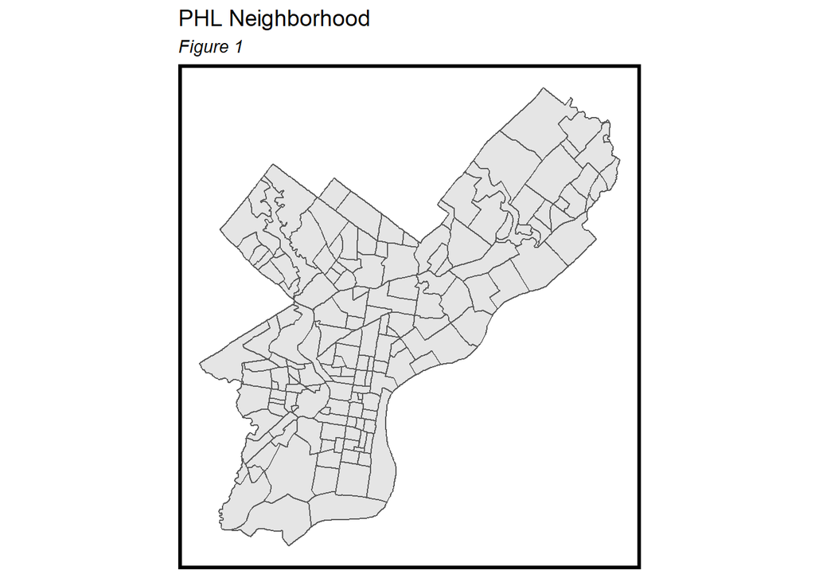

```r
#Permit Data, PHL boundary, PHL block groups, PHL nhoods, base fishnet
permits <-
  st_read("https://phl.carto.com/api/v2/sql?q=SELECT+*+FROM+permits+WHERE+permitissuedate+>=+'2010-01-01'+AND+permitissuedate+<+'2019-01-01'AND+typeofwork+=+'NEW+CONSTRUCTION'&filename=permits&format=geojson&skipfields=cartodb_id")%>%
  st_transform('EPSG:3857')

phlBound <-
  st_read("http://data.phl.opendata.arcgis.com/datasets/063f5f85ef17468ebfebc1d2498b7daf_0.geojson")%>%
  st_transform('EPSG:3857')

phlblockgroups <-
  st_read("http://data.phl.opendata.arcgis.com/datasets/2f982bada233478ea0100528227febce_0.geojson")%>%
  st_transform('EPSG:3857') %>%
  rename(GEOID=GEOID10)

phlblockgroups<- transform(phlblockgroups, GEOID=as.double(GEOID))

typeof(phlblockgroups$GEOID)

neighborhoods <-
  st_read("Neighborhoods_Philadelphia") %>%
  st_transform('EPSG:3857')

ggplot() +
  geom_sf(data = neighborhoods)+
  labs(title = "PHL Neighborhood",
       subtitle = "Figure 1") +
  mapTheme()
```

In order to make accurate predictions, we focus on high spatial resolution data to create a hyperlocalized model. Below, a fishnet grid is created using the Philadelphia boundary loaded above. We then sum up the count of permits per grid cell and join it to the fishnet. Below is a map of the concentration of permits across the city with the highest around the Center City neighborhood.

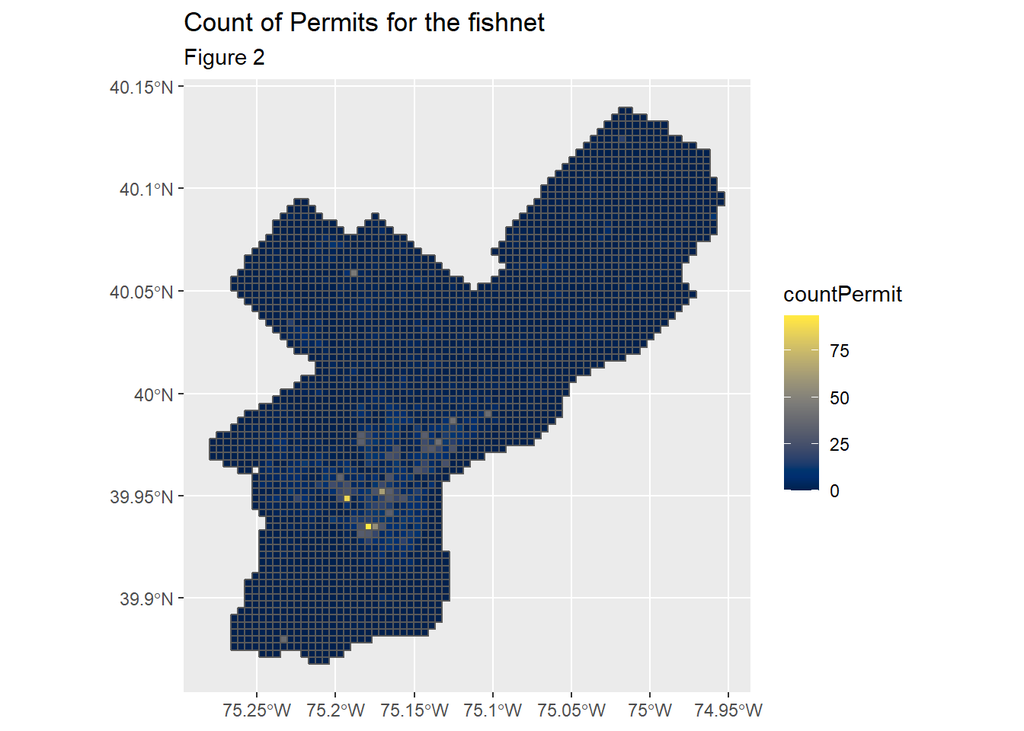

```r
fishnet <-
  st_make_grid(phlBound, cellsize = 500, square=TRUE) %>%
  .[phlBound]%>%
  st_sf() %>%
  mutate(uniqueID = rownames(.))

permit_net <-
  dplyr::select(permits) %>%
  mutate(countPermit = 1) %>%
  aggregate(., fishnet, sum) %>%
  mutate(countPermit = replace_na(countPermit, 0),
         uniqueID = rownames(.),
         cvID = sample(round(nrow(fishnet) / 24),
                       size=nrow(fishnet), replace = TRUE))

  ggplot() +
  geom_sf(data = permit_net, aes(fill = countPermit)) + #want to make this construction colors
  scale_fill_viridis(option="cividis")+
  labs(title = "Count of Permits for the fishnet",
       subtitle = "Figure 2")
```

```r
  mapTheme()
```

Below we analyze the total distribution of permits across Philly in order to determine which regression type to use in our model. Because gentrification tends to occur in a select few neighborhoods at a single time, it is reasonable for many grid cells to have 0 or few permits. When the data is distributed this way, a Poisson Regression is appropriate. However, further data exploration of the predictors of our model is needed before proceeding with the regression.

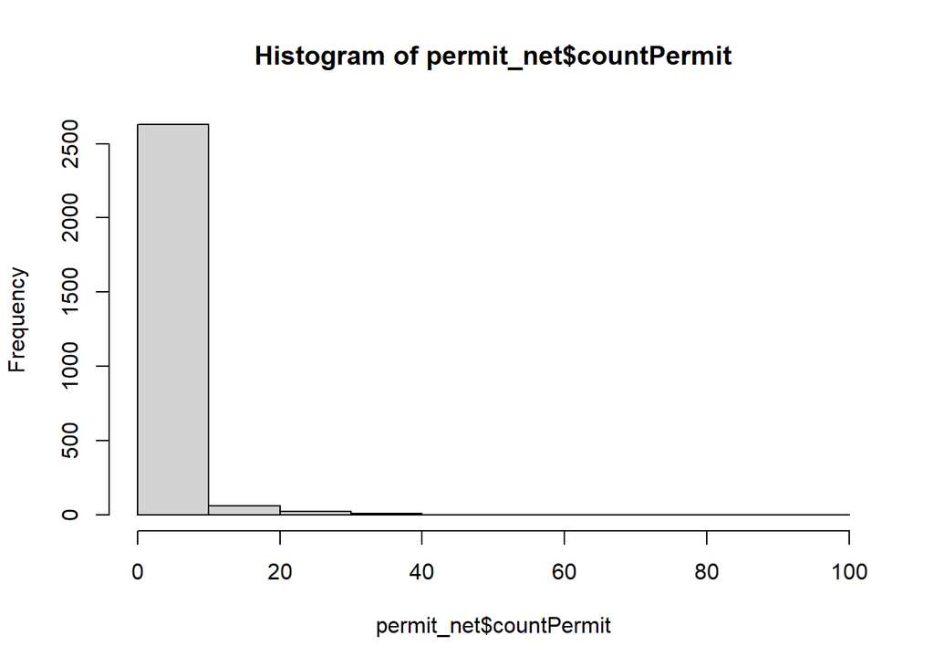

```r
hist(permit_net$countPermit)
```

# Feature Engineering

The features that inform the model are telling factors of neighborhood change that we suspect lead to new construction and thus are potential drivers of gentrification. In this section, each feature is described and we explain whether or not it was included in the model and why.

### Eviction Data

The first of these factors we observe is evictions across the city of Philadelphia. Data from Matthew Desmond’s Eviction Lab is loaded for Philly which consisted of over 200,000 observations. The size and format of the data set created a few computational issues. The data is available at the block group level; however, to achieve high spatial resolution as previously explained, we must manipulate the data such that it is available at a grid cell level. This involved interpolating the value assigned to each block group across the applicable grid cells. Because of this process, we filtered the data set by a few select years to decrease the size and run time. It is important to note the selection bias present in this filtering process and that if different years were selected, it may change the results of the model slightly.

```r
#Eviction data
evictions <-read.csv("philly_eviction_data.csv")%>%
  filter(year==2010|year==2014|year==2016)

evictions.geom <- left_join(evictions,phlblockgroups, by="GEOID") %>%
  st_as_sf()%>% #generate interpolation to grid cell
  st_transform('EPSG:3857')%>%
  mutate(Legend = "Evictions")
```

There are a few metrics we can use to evaluate the relationship between evictions and new construction permits filed. The first calculated below is the average number of evictions per grid cell. This feature is simple to communicate and easy to understand in the context of the model and is explored further in the Correlation Test section.

```r
evictions_net <-
  evictions.geom %>%
  st_sf() %>%
  mutate(evictionsTotal=ifelse(is.na(evictions.geom$evictions),0,evictions.geom$evictions))%>%
  dplyr::select(evictionsTotal) %>%
  aggregate(., fishnet, mean)%>%
  mutate(Legend="evictionsTotal")

#mutate the variable your after for tracts
tractJawn <-
 evictions.geom %>%
  st_sf() %>%
  mutate(evictionsTotal = ifelse(is.na(evictions.geom$evictions),0,evictions.geom$evictions))

#interpolate from tracts to fishnet. Look up the `extensive` parameter.
interpolateJawn <-
  dplyr::select(tractJawn, evictionsTotal) %>%
  st_interpolate_aw(., fishnet, extensive = TRUE)

#for all vars net later
evictions_net.long<-
  gather(evictions_net, Variable, value, -geometry,-Legend)%>%
  dplyr::select(-Legend)

evictions_net.long<-
  st_join(evictions_net.long, fishnet, join=st_within)
```

Another metric calculated below is the Median Eviction Rate per grid cell. The map presented below shows the calculation by block group and by grid cell. We noticed that there is a census tract in North Philly that has a high median eviction rate but a nonexistent residential population as that is the tract where the Northeast Philadelphia Airport is located. This creates a false illusion of a hotspot for median eviction rates, so this feature is not included in the model.

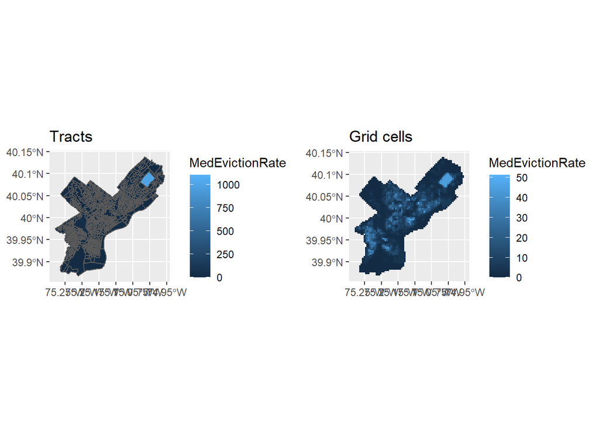

```r
evictions_net2 <-
  evictions.geom %>%
  st_sf() %>%
   mutate(MedEvictionRate=ifelse(is.na(evictions.geom$eviction.rate),0,evictions.geom$eviction.rate))%>%
  dplyr::select(MedEvictionRate) %>%
  aggregate(., fishnet, median)%>%
  mutate(Legend="MedEvictionRate")

#mutate the variable your after for tracts
tractJawn <-
 evictions.geom %>%
  st_sf() %>%
  mutate(MedEvictionRate=ifelse(is.na(evictions.geom$eviction.rate),0,evictions.geom$eviction.rate))

#interpolate from tracts to fishnet. Look up the `extensive` parameter.
interpolateJawn <-
  dplyr::select(tractJawn, MedEvictionRate) %>%
  st_interpolate_aw(., fishnet, extensive = TRUE)

#for all vars net later
evictions_net2.long<-
  gather(evictions_net2, Variable, value, -geometry,-Legend)%>%
  dplyr::select(-Legend)

evictions_net2.long<-
  st_join(evictions_net2.long, fishnet, join=st_within)

#map
grid.arrange(
  ggplot() + geom_sf(data=tractJawn, aes(fill = MedEvictionRate)) + ggtitle("Tracts"),
  ggplot() + geom_sf(data=interpolateJawn, aes(fill = MedEvictionRate), colour=NA) + ggtitle("Grid cells"),
  ncol=2)
```

Instead, we calculate the Average Eviction Filing rate below per grid cell. The resulting map is closer to what we would expect for the data, and thus is included later in the Correlation Test section.

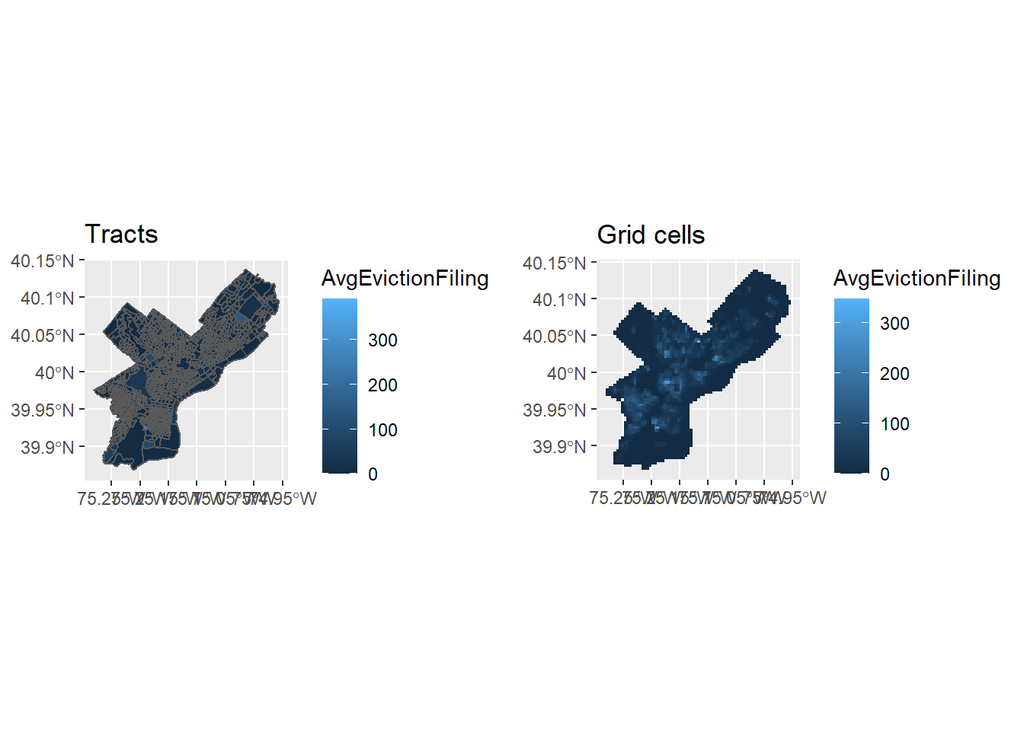

```r
evictions_net3 <-
  evictions.geom %>%
  st_sf() %>%
  mutate(AvgEvictionFiling=ifelse(is.na(evictions.geom$eviction.filings),0,evictions.geom$eviction.filings))  %>%
  dplyr::select(AvgEvictionFiling) %>%
  aggregate(., fishnet, mean)%>%
  mutate(Legend="AvgEvictionFiling")

#mutate the variable your after for tracts
tractJawn <-
 evictions.geom %>%
  st_sf() %>%
  mutate(AvgEvictionFiling=ifelse(is.na(evictions.geom$eviction.filings),0,evictions.geom$eviction.filings))

#interpolate from tracts to fishnet. Look up the `extensive` parameter.
interpolateJawn <-
  dplyr::select(tractJawn, AvgEvictionFiling) %>%
  st_interpolate_aw(., fishnet, extensive = TRUE)

#for all vars net later
evictions_net3.long<-
  gather(evictions_net3, Variable, value, -geometry,-Legend)%>%
  dplyr::select(-Legend)

evictions_net3.long<-
  st_join(evictions_net3.long, fishnet, join=st_within)

#map
grid.arrange(
  ggplot() + geom_sf(data=tractJawn, aes(fill = AvgEvictionFiling)) + ggtitle("Tracts"),
  ggplot() + geom_sf(data=interpolateJawn, aes(fill = AvgEvictionFiling), colour=NA) + ggtitle("Grid cells"),
  ncol=2)
```

We also calculated the Median Filing Rate per each grid cell, but uncovered the same issue as the Median Eviction Rate per grid cell. This feature is also not included in the model.

```r
evictions_net4 <-
  evictions.geom %>%
  st_sf() %>%
  mutate(MedFilingRate=ifelse(is.na(evictions.geom$eviction.filing.rate),0,evictions.geom$eviction.filing.rate))  %>%
  dplyr::select(MedFilingRate) %>%
  aggregate(., fishnet, median)%>%
  mutate(Legend="MedFilingRate")

#mutate the variable your after for tracts
tractJawn <-
 evictions.geom %>%
  st_sf() %>%
  mutate(MedFilingRate=ifelse(is.na(evictions.geom$eviction.filing.rate),0,evictions.geom$eviction.filing.rate))

#interpolate from tracts to fishnet. Look up the `extensive` parameter.
interpolateJawn <-
  dplyr::select(tractJawn, MedFilingRate) %>%
  st_interpolate_aw(., fishnet, extensive = TRUE)

#for all vars net later
evictions_net4.long<-
  gather(evictions_net4, Variable, value, -geometry, -Legend)%>%
  dplyr::select(-Legend)

evictions_net4.long<-
  st_join(evictions_net4.long, fishnet, join=st_within)
```

### Property Tax Delinquency

Another factor we examined is property tax delinquency data from Open Data Philly. Below, we read in this data using a SQL query to filter for just the city of Philadelphia. As mentioned in the introduction, increasing costs are often a signal of gentrification as rising home prices drive long-time residents out of the neighborhood. We expect that areas of high property taxes would be highly associated with areas of new construction permits filed.

The first feature we engineer from this data is the total amount of taxes owed per grid cell. Because this data is available at a high spatial resolution (point data) we do not have to repeat the interpolation method used for the evictions data.

```r
#Tax Delinquency data
tax <-
  st_read("https://phl.carto.com/api/v2/sql?q=SELECT+*+FROM+real_estate_tax_delinquencies+WHERE+mailing_city+=+'PHILADELPHIA'&filename=real_estate_tax_delinquencies&format=geojson&skipfields=cartodb_id")%>%
  st_as_sf(coords = c("lon", "lat"), crs = 4326, agr = "constant") %>%
  st_transform('EPSG:3857')%>%
  mutate(Legend = "Tax")

tax_net <-
  st_join(tax, fishnet, join=st_within) %>%
  st_drop_geometry() %>%
  group_by(uniqueID,Legend) %>%
  summarize(totalOwed=mean(total_due,n=n()),)%>%
  full_join(fishnet, by = "uniqueID") %>%
  spread(Legend, totalOwed, fill=0) %>%
  st_sf() %>%
  dplyr::select(-`<NA>`) %>%
  na.omit() %>%
  ungroup()

tax_net.long <-
  gather(tax_net, Variable, value, -geometry, -uniqueID)

# ggplot() +
#   geom_sf(data = tax_net.long, aes(fill=value), colour=NA) + #change the scale of this?
#   scale_fill_viridis() +
#   labs(title="Average total amount due in taxes by Fishnet",
#        subtitle = "Philadelphia - last assessment: 2020") +
#   mapTheme()

#Map of Places with lots of actionable
#places of high bankruptcy?
```

Another feature we engineered were the total number of bankruptcy occurrences per grid cell. At the start of our feature engineering process, this returned a favorable result; however, it appears that Open Data Philly updated this data set and the results are no longer helpful in informing our model as all data points resulted in 0 occurrences of bankruptcy. Thus, this feature is not currently included in the model, but with updated data, could be in the future.

```r
#this data changed

# tax2<-
#   tax %>%
#   mutate(Legend="taxBankruptcy")
#
# tax_net2 <-
#   st_join(tax2, fishnet, join=st_within) %>%
#   st_drop_geometry() %>%
#   group_by(uniqueID,Legend) %>%
#   summarize(bankrupt=sum(bankruptcy=='true'))%>%
#   full_join(fishnet, by = "uniqueID") %>%
#   spread(Legend, bankrupt, fill=0) %>%
#   st_sf() %>%
#   dplyr::select(-`<NA>`) %>%
#   na.omit() %>%
#   ungroup()
#
# tax_net2.long <-
#   gather(tax_net2, Variable, value, -geometry, -uniqueID)

# ggplot() +
#   geom_sf(data = tax_net2.long, aes(fill=value), colour=NA) + #change the scale of this?
#   scale_fill_viridis() +
#   labs(title="Sum where Bankrupt is True by Fishnet",
#        subtitle = "Philadelphia - last assessment: 2020") +
#   mapTheme()
```

The final feature for our tax data examines if the amount due is actionable or non-actionable. Accounts that are in payment agreement, bankruptcy, or overdue but not yet delinquent are considered “not actionable.” The following code chunk calculates the number of properties that have accounts considered to be “actionable” per grid cell.

```r
tax3<-
  tax %>%
  mutate(Legend="taxActionable")

tax_net3 <-
  st_join(tax3, fishnet, join=st_within) %>%
  st_drop_geometry() %>%
  group_by(uniqueID,Legend) %>%
  summarize(actionable=sum(is_actionable=='true'))%>%
  full_join(fishnet, by = "uniqueID") %>%
  spread(Legend, actionable, fill=0) %>%
  st_sf() %>%
  dplyr::select(-`<NA>`) %>%
  na.omit() %>%
  ungroup()

tax_net3.long <-
  gather(tax_net3, Variable, value, -geometry, -uniqueID)

# ggplot() +
#   geom_sf(data = tax_net3.long, aes(fill=value), colour=NA) + #change the scale of this?
#   scale_fill_viridis() +
#   labs(title="Sum where is_actionable is True by Fishnet",
#        subtitle = "Philadelphia - last assessment: 2020") +
#   mapTheme()
```

### Hipster Features

The stereotypical characteristics of newly gentrified areas are hipster coffee shops and crunchy grocery stores. A 2018 Harvard Study using Yelp reviews confirms that Starbucks cafes are strongly associated with a 0.5% increase in housing prices. Further, the study states that gentrification is associated with an increase in amenities like grocery stores, cafes, and bars (https://www.cnbc.com/2018/09/04/starbucks-openings-predcit-higher-home-prices-says-harvard-study.html) . Thus, we include data on Starbucks locations and grocery stores as likely indicators of gentrification.

Below, we read in the locations of Starbucks in Philadelphia and calculate the total number of locations per grid cell for our fishnet.

```r
#Starbucks data <- kaggle datasets download -d starbucks/store-locations
starbucks <- read.csv("starbucks//directory.csv")
starbucks<- filter(starbucks, City=="Philadelphia") %>%
  st_as_sf(coords = c("Longitude", "Latitude"), crs = 4326, agr = "constant") %>%
  st_transform('EPSG:3857') %>%
  mutate(Legend = "Starbucks")

starbucks_net <-
  st_join(starbucks, fishnet, join=st_within) %>%
  st_drop_geometry() %>%
  group_by(uniqueID,Legend) %>%
  summarize(count = n()) %>%
  full_join(fishnet) %>%
  spread(Legend, count, fill=0) %>%
  st_sf() %>%
  dplyr::select(-`<NA>`) %>%
  na.omit() %>%
  ungroup()

# ggplot() +
#   geom_sf(data = starbucks_net, aes(fill=Starbucks), colour=NA) + #can we adjust the scale?
#   scale_fill_viridis() +
#   labs(title="Starbucks by Fishnet",
#        subtitle = "Philadelphia 2000-2016") +
#   mapTheme()
```

Next, we replicate the same process for the grocery store data from Open Data Philly. The total number of areas with moderate to high access to grocery stores is calculated per grid cell.

```r
#Grocery Store Access data
grocerystore<- st_read("http://data-phl.opendata.arcgis.com/datasets/53b8a1c653a74c92b2de23a5d7bf04a0_0.geojson")%>%
  st_transform('EPSG:3857') %>%
  rename(GEOID=GEOID10)

grocerystore1<- filter(grocerystore, HPSS_ACCESS=='Moderate or High Access')%>%
  st_as_sf(coords = c("Longitude", "Latitude"), crs = 4326, agr = "constant") %>%
  st_transform('EPSG:3857') %>%
  mutate(Legend = "Grocery")

grocery_net <-
  st_join(grocerystore1, fishnet, join=st_within) %>%
  st_drop_geometry() %>%
  group_by(uniqueID,Legend) %>%
  summarize(count = n()) %>% #Should we also do vehicle availability? #also could do PCT_HPSS above 50%
  full_join(fishnet) %>%
  spread(Legend, count, fill=0) %>%
  st_sf() %>%
  dplyr::select(-`<NA>`) %>%
  na.omit() %>%
  ungroup()

# #Do we need to change this because its a binary?
# ggplot() +
#   geom_sf(data = grocery_net, aes(fill=Grocery), colour=NA) +
#   scale_color_manual(values = c("constructionpalette")) +
#   labs(title="High Access Groceries by Fishnet",
#        subtitle = "Philadelphia 2018") +
#   mapTheme()
```

Lastly, another stereotypical characteristic of hipster neighborhoods is presence of nature and greenery. Below, we read in a tree canopy data set from Open Data Philly and calculate the number of trees per grid cell.

```r
treeinventory<- st_read("http://data.phl.opendata.arcgis.com/datasets/957f032f9c874327a1ad800abd887d17_0.geojson")%>%
  st_transform('EPSG:3857') %>%
  mutate(Legend = "Tree")
  #rename(GEOID=GEOID10)
  #SPATIAL join of points to fishnets
treeinventory_net <-
  st_join(treeinventory, fishnet, join=st_within)%>%
  st_drop_geometry() %>%
  group_by(uniqueID, Legend) %>%
  summarize(count = n()) %>%
    full_join(fishnet) %>%
    spread(Legend, count, fill=0) %>%
    st_sf() %>%
    dplyr::select(-`<NA>`) %>%
    na.omit() %>%
    ungroup()

treeinventory_net$Tree=as.numeric(treeinventory_net$Tree)
treeinventory_net<-
  treeinventory_net%>%
  mutate(Legend="Tree")

#
#   ggplot() +
#   geom_sf(data = treeinventory_net, aes(fill=Tree)) + #I want to create range of values from 0-480 to color
#   scale_colour_manual(values="Tree")
#   labs(title="Tree Inventory by Fishnet",
#        subtitle = "Philadelphia 2018") +
#   mapTheme()
```

### All Risk Factors by Fishnet

Because our data came in various forms, we perform some data wrangling and manipulation so that we can plot the fishnets created above side by side.

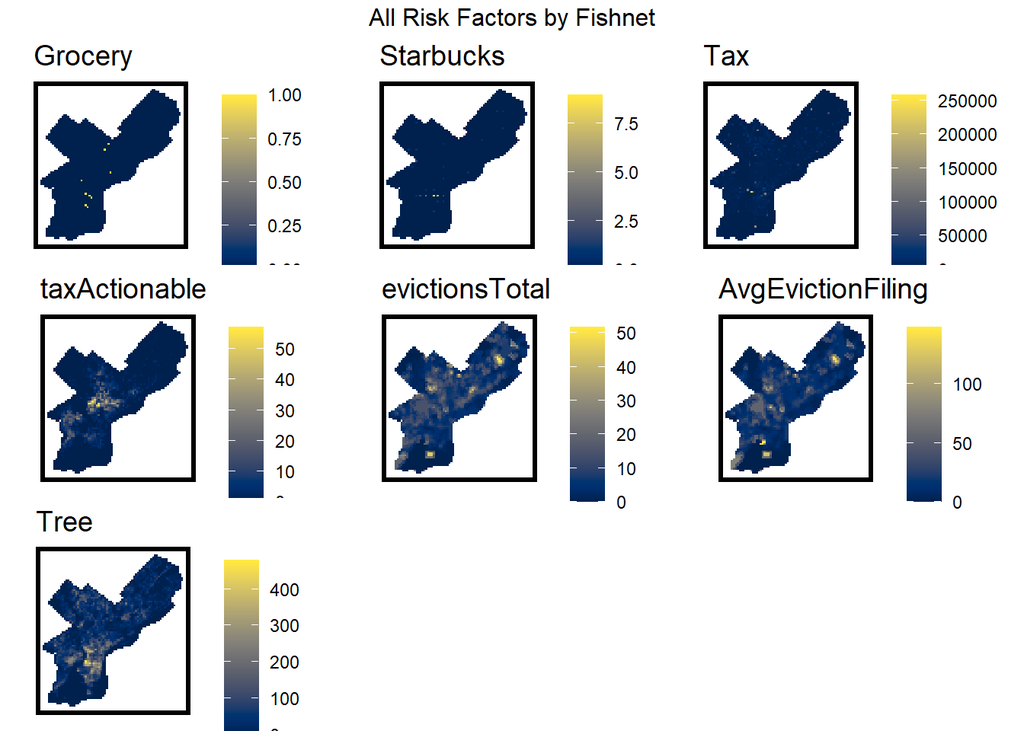

```r
#All Risk Factors by Fishnet
starbucks_short<-starbucks%>%
  dplyr::select(geometry,Legend)

grocery_short<-grocerystore1%>%
  dplyr::select(geometry,Legend)

vars_net <-
  rbind(starbucks_short, grocery_short) %>%
  st_join(., fishnet, join=st_within) %>%
  st_drop_geometry() %>%
  group_by(uniqueID, Legend) %>%
  summarize(count = n()) %>%
  full_join(fishnet) %>%
  spread(Legend, count, fill=0) %>%
  st_sf() %>%
  dplyr::select(-`<NA>`) %>%
  na.omit() %>%
  ungroup

vars_net.long <-
  gather(vars_net, Variable, value, -geometry, -uniqueID)

tree_long <-
  gather(treeinventory_net, Variable, value, -geometry, -uniqueID,-Legend)%>%
  dplyr::select(-Legend)

allvars.long <-
  rbind(vars_net.long,tax_net.long, tax_net3.long,evictions_net.long,evictions_net3.long,tree_long)

vars <- unique(allvars.long$Variable)
mapList <- list()

for(i in vars){
  mapList[[i]] <-
  ggplot() +
    geom_sf(data = filter(allvars.long, Variable == i), aes(fill=value), colour=NA) +
    scale_fill_viridis(name="", option="cividis") +
    labs(title=i) +
    mapTheme()}

do.call(grid.arrange,c(mapList, ncol=3, top="All Risk Factors by Fishnet"))
```

We can see from the resulting fishnets that the Grocery, Starbucks, and Tax data may not inform our model as strongly as the other features. Below, we define a nearest neighbor function to calculate the average distance between a newly filed construction permit and the target observation. We perform some more data wrangling so that we can plot the resulting correlations side by side in the Correlation Test section. The resulting nearest neighbor features by fishnet are presented below.

```r
evictions_net <-
  evictions_net %>%
  st_join(., fishnet, join=st_within)

vars_net2<-
  vars_net%>%
  st_drop_geometry()%>%
  full_join(evictions_net,vars_net,by="uniqueID")%>%
  st_sf()%>%
  dplyr::select(-Legend)

evictions_net3 <-
  evictions_net3 %>%
  st_join(., fishnet, join=st_within)

vars_net2 <-
  vars_net2%>%
  st_drop_geometry()%>%
  full_join(evictions_net3,vars_net2,by="uniqueID")%>%
  st_sf()%>%
  dplyr::select(-Legend)

vars_net2<-
  vars_net2%>%
  st_drop_geometry()%>%
  full_join(tax_net,vars_net2,by="uniqueID")%>%
  st_sf()

vars_net2<-
  vars_net2%>%
  st_drop_geometry()%>%
  full_join(tax_net3,vars_net2,by="uniqueID")%>%
  st_sf()

vars_net2 <-
  vars_net2%>%
  st_drop_geometry()%>%
  full_join(treeinventory_net,vars_net2,by="uniqueID")%>%
  st_sf()%>%
  dplyr::select(-Legend)
```

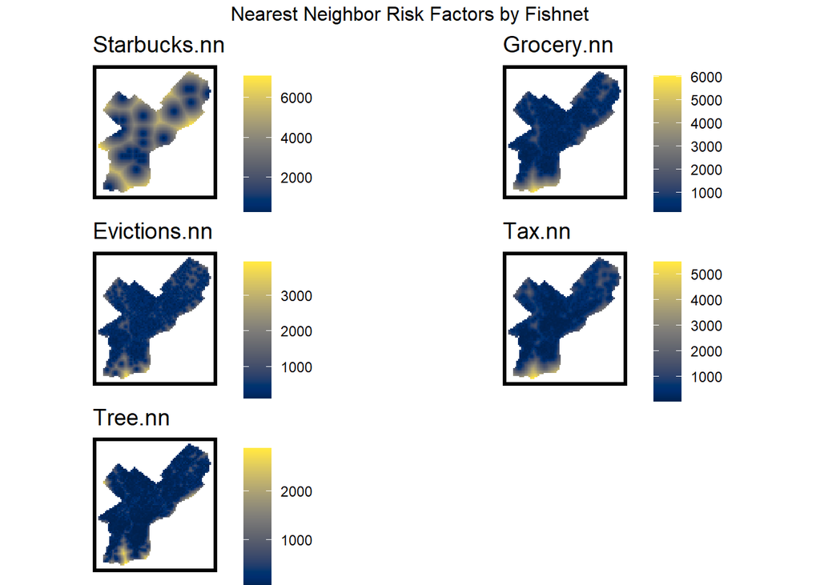

```r
nn_function <- function(measureFrom,measureTo,k) {
  measureFrom_Matrix <-
    as.matrix(measureFrom)
  measureTo_Matrix <-
    as.matrix(measureTo)
  nn <-
    get.knnx(measureTo, measureFrom, k)$nn.dist
  output <-
    as.data.frame(nn) %>%
    rownames_to_column(var = "thisPoint") %>%
    gather(points, point_distance, V1:ncol(.)) %>%
    arrange(as.numeric(thisPoint)) %>%
    group_by(thisPoint) %>%
    summarize(pointDistance = mean(point_distance)) %>%
    arrange(as.numeric(thisPoint)) %>%
    dplyr::select(-thisPoint) %>%
    pull()

  return(output)
}

st_c <- st_coordinates
st_coid <- st_centroid

#nn function requires both input layers to be points
vars_net2 <-
  vars_net2 %>%
  mutate(
    Starbucks.nn =
      nn_function(st_c(st_coid(vars_net2)), st_c(starbucks),1),
    Grocery.nn =
      nn_function(st_c(st_coid(vars_net2)), st_c(st_coid(grocerystore1)),1),
    Evictions.nn =
      nn_function(st_c(st_coid(vars_net2)), st_c(st_coid(evictions.geom)),3),
    Tax.nn=
      nn_function(st_c(st_coid(vars_net2)), st_c(tax),3),
    Tree.nn=
      nn_function(st_c(st_coid(vars_net2)),st_c(treeinventory),3))

vars_net.long.nn <-
  dplyr::select(vars_net2, ends_with(".nn")) %>%
  gather(Variable, value, -geometry)

vars2 <- unique(vars_net.long.nn$Variable)

mapList <- list()

for(i in vars2){
  mapList[[i]] <-
    ggplot() +
    geom_sf(data = filter(vars_net.long.nn, Variable == i), aes(fill=value), colour=NA) +
    scale_fill_viridis(name="", option="cividis") +
    labs(title=i) +
    mapTheme()}

#NOTE: for tax.nn and eviction.nn fishnets now show counts instead of average evictions or total due
do.call(grid.arrange,c(mapList, ncol = 2, top = "Nearest Neighbor Risk Factors by Fishnet"))
```

The results for Starbucks locations and grocery store locations are more favorable because there is more information per grid cell.

As our last predictor, we include the distance to Center City in order to account for a unique spatial process in our predictions. We can observe from our Count of Permits by Fishnet (Figure 2) plot that there is a large concentration of new construction permits around the Center City neighborhood. It is likely that as the value of one neighborhood increases, the value of the surrounding neighborhoods will increase. Thus, we include the distance to Center City as a feature because as new construction permits are filed here, it is likely an increasing amount of investment will occur in the surrounding neighborhoods.

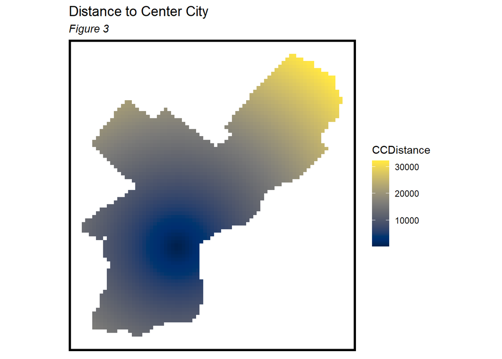

```r
cityhall <-
  filter(neighborhoods, NAME == "CENTER_CITY") %>%
  st_centroid()

vars_net2$CCDistance =
  st_distance(st_centroid(vars_net2),cityhall) %>%
  as.numeric()

ggplot() +
  geom_sf(data = vars_net2, aes(fill = CCDistance), color = NA) +
  scale_fill_viridis(option="cividis") +
  labs(title = "Distance to Center City",
       subtitle = "Figure 3") +
  mapTheme()
```

### Creating the Final Net

Lastly, we perform a final join so all of our features are in the same dataframe as our dependent variable. Additionally, we join this to our neighborhood boundary data set so we can analyze the results of the model across spatial bounds later.

```r
final_net <-
  left_join(permit_net, st_drop_geometry(vars_net2), by="uniqueID")

final_net <-
  st_centroid(final_net) %>%
  st_join(dplyr::select(neighborhoods, NAME)) %>%
  st_drop_geometry() %>%
  left_join(dplyr::select(final_net, geometry, uniqueID)) %>%
  st_sf() %>%
  na.omit()
```

# Exploring Spatial Processes

In this section, we perform a couple of statistical tests to analyze the spatial process of both our dependent variable and our predictors.

### Local Moran’s I

First, we use our final net created above to calculate a Statistic known as Local Moran’s I. The null hypothesis of the test is that the permit count at a given location is randomly distributed relative to its immediate neighbors. Thus, a high Local Moran’s I indicates spatial clustering. The results of the test are presented below.

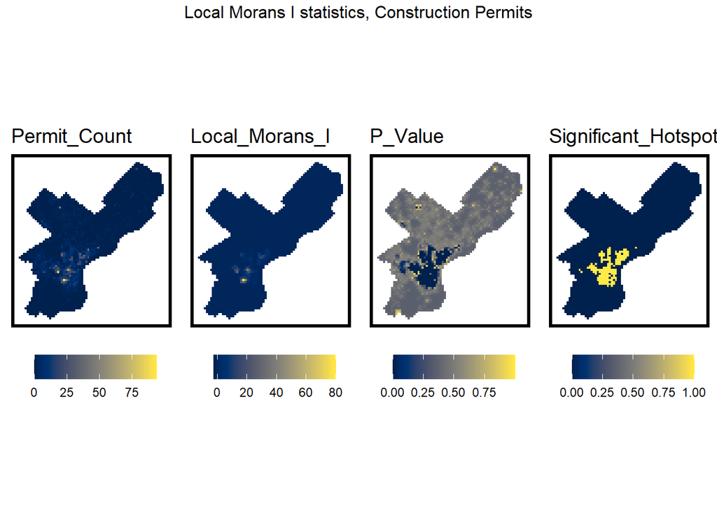

```r
#Creating queen weight neighbors for Moran's I
final_net.nb <- poly2nb(as_Spatial(final_net), queen=TRUE)
final_net.weights <- nb2listw(final_net.nb, style="W", zero.policy=TRUE)

#Running Local Moran's I
final_net.localMorans <-
  cbind(
    as.data.frame(localmoran(final_net$countPermit, final_net.weights)),
    as.data.frame(final_net)) %>%
  st_sf() %>%
  dplyr::select(Permit_Count = countPermit,
                Local_Morans_I = Ii,
                P_Value = `Pr(z > 0)`) %>%
  mutate(Significant_Hotspots = ifelse(P_Value <= 0.005, 1, 0)) %>% #change pvalue?
  gather(Variable, Value, -geometry)

vars <- unique(final_net.localMorans$Variable)
varList <- list()

for(i in vars){
  varList[[i]] <-
    ggplot() +
    geom_sf(data = filter(final_net.localMorans, Variable == i),
            aes(fill = Value), colour=NA) +
    scale_fill_viridis(name="", option="cividis") +
    labs(title=i) +
    mapTheme() + theme(legend.position="bottom")}

do.call(grid.arrange,c(varList, ncol = 4, top = "Local Morans I statistics, Construction Permits"))
```

Using a p-value of 0.005, we observe that there is significant spatial clustering in the Center City and surrounding neighborhoods. This information is helpful when considering the generalizability of our model. An effective model will be able to predict in the hotspots as well as in the coldspots. Additionally, this spatial feature can be included in the model to control for the observed local clustering.

In order to include the spatial process in our model, we calculate the distance to the identified hotspots in the code chunk below. The results are presented below in Figure 4.

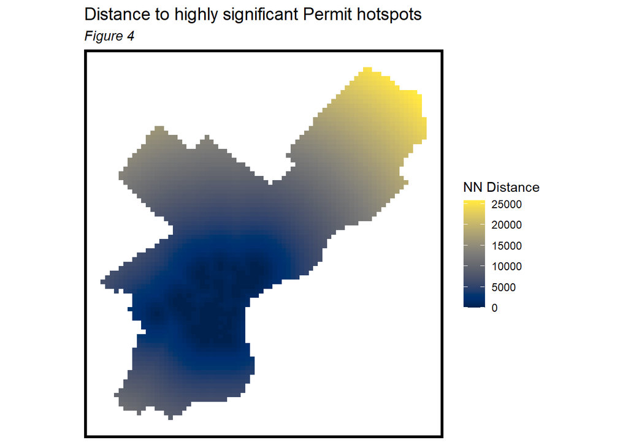

```r
#significance to hotspots
final_net <-
  final_net %>%
  mutate(Permit.isSig =
           ifelse(localmoran(final_net$countPermit,
                             final_net.weights)[,5] <= 0.00001, 1, 0)) %>% #does this need to changed?
  mutate(Permit.isSig.dist =
           nn_function(st_coordinates(st_centroid(final_net)),
                       st_coordinates(st_centroid(
                         filter(final_net, Permit.isSig == 1))), 1))
ggplot() +
  geom_sf(data = final_net, aes(fill=Permit.isSig.dist), colour=NA) +
  scale_fill_viridis(name="NN Distance", option="cividis") +
  labs(title="Distance to highly significant Permit hotspots",
       subtitle = "Figure 4") +
  mapTheme()
```

### Correlation Tests

The second test we conduct is a series of correlation tests to see if our risk factors are highly associated to the count of newly filed construction permits. The results are presented below in Figure 5.

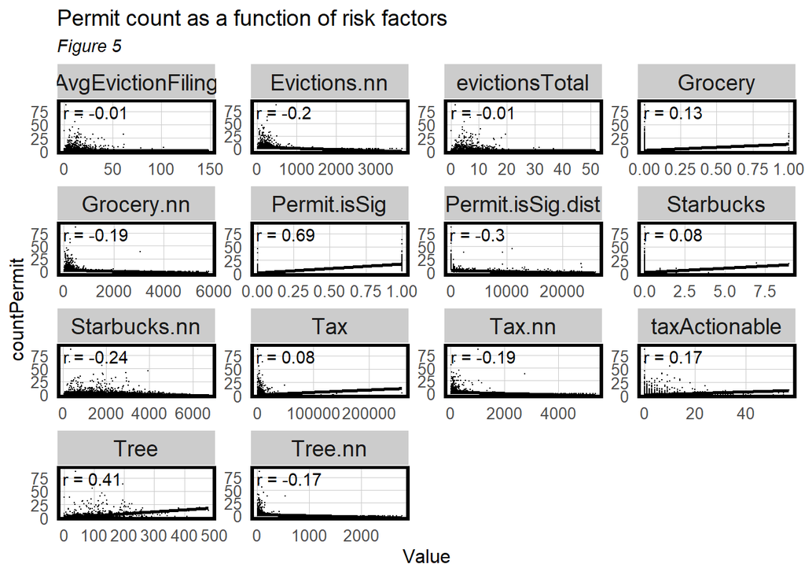

```r
#Correlation
#This helps us decide what features to include in our model. Make sure to not include features that are collinear.
#Sometimes that is the case with count and nn
correlation.long <-
  st_drop_geometry(final_net) %>%
  dplyr::select(-uniqueID, -cvID, -CCDistance, -NAME ) %>%
  gather(Variable, Value, -countPermit)

correlation.cor <-
  correlation.long %>%
  group_by(Variable) %>%
  summarize(correlation = cor(Value, countPermit, use = "complete.obs"))

ggplot(correlation.long, aes(Value, countPermit)) +
  geom_point(size = 0.1) +
  geom_text(data = correlation.cor, aes(label = paste("r =", round(correlation, 2))),
            x=-Inf, y=Inf, vjust = 1.5, hjust = -.1) +
  geom_smooth(method = "lm", se = FALSE, colour = "black") +
  facet_wrap(~Variable, ncol = 4, scales = "free") +
  labs(title = "Permit count as a function of risk factors",
       subtitle= "Figure 5") +
  plotTheme()
```

The results indicate which of our features are strongly correlated with the filing of new construction permits. We can see that the two spatial features (Permit.isSig and Permit.isSig.dist) are highly correlated which supports our previous statement that increasing values in one neighborhood affect its surrounding neighborhoods. Additionally, we can confirm that the nearest neighbor feature for Starbucks locations (Starbucks.nn), total amount of taxes owed (Tax.nn), and number of evictions (Evictions.nn) are more strongly correlated than their point locations. These correlations help us to determine which features are worth including in the model.

# Building the Model

Now we can build the model! As previously stated, we determined that a Poisson Regression is most appropriate for the distribution of our construction permit data. Below, we set up to run this regression twice. Once, with our highly correlated features and again, with the same features but add in the two features that account for the spatial process of our dependent variable.

```r
##Poisson Regression because there are a lot of 0s in the distribution of DV
reg.vars <- c("Starbucks.nn", "Grocery.nn", "evictionsTotal","AvgEvictionFiling","taxActionable", "Tax","Tree","Tree.nn","CCDistance")
#Adding in the spatial component of the dependent variable
reg.ss.vars <- c("Starbucks.nn", "Grocery.nn", "evictionsTotal","AvgEvictionFiling","taxActionable", "Tax","Tree","Tree.nn","CCDistance","Permit.isSig","Permit.isSig.dist")
```

# Cross-validated Poisson Regression

Two different methods of cross-validation are used below. First we define the crossValidate function that will be used in both methods. During cross-validation, our entire data set is partitioned such that the model is trained on one set of data and then predicts results based on the remaining set of data. The two methods here differ in the way the data set is split up. The first method performed is known as k-fold cross-validation in which one random fold of data is left out of the training set each time until all folds have been tested on. The second method performed is known as leave-one-group-out, or LOGO, cross-validation in which one designated group of data is left out of the training set each time until all groups have been tested on.

For LOGO CV, we indicate that each group of data will be a neighborhood. We expect that this method will have more accurate results, because it accounts for the spatial process behind neighborhood dynamics.

```r
crossValidate <- function(dataset, id, dependentVariable, indVariables) {

  allPredictions <- data.frame()
  cvID_list <- unique(dataset[[id]])

  for (i in cvID_list) {

    thisFold <- i
    cat("This hold out fold is", thisFold, "\n")

    fold.train <- filter(dataset, dataset[[id]] != thisFold) %>% as.data.frame() %>%
      dplyr::select(id, geometry, indVariables, dependentVariable)
    fold.test  <- filter(dataset, dataset[[id]] == thisFold) %>% as.data.frame() %>%
      dplyr::select(id, geometry, indVariables, dependentVariable)

    regression <-
      glm(countPermit ~ ., family = "poisson",
          data = fold.train %>%
            dplyr::select(-geometry, -id))

    thisPrediction <-
      mutate(fold.test, Prediction = predict(regression, fold.test, type = "response"))

    allPredictions <-
      rbind(allPredictions, thisPrediction)

  }
  return(st_sf(allPredictions))
}

reg.cv <- crossValidate(
  dataset = final_net,
  id = "cvID",
  dependentVariable = "countPermit",
  indVariables = reg.vars) %>%
  dplyr::select(cvID = cvID, countPermit, Prediction, geometry)

reg.ss.cv <- crossValidate(
  dataset = final_net,
  id = "cvID",
  dependentVariable = "countPermit",
  indVariables = reg.ss.vars) %>%
  dplyr::select(cvID = cvID, countPermit, Prediction, geometry)

reg.spatialCV <- crossValidate(
  dataset = final_net,
  id = "NAME",
  dependentVariable = "countPermit",
  indVariables = reg.vars) %>%
  dplyr::select(cvID = NAME, countPermit, Prediction, geometry)

reg.ss.spatialCV <- crossValidate(
  dataset = final_net,
  id = "NAME",
  dependentVariable = "countPermit",
  indVariables = reg.ss.vars) %>%
  dplyr::select(cvID = NAME, countPermit, Prediction, geometry)
```

# Analyzing Results across Space

To analyze the results of the model, we compare the resulting predictions to the observations of reality to calculate the number of errors.

```r
reg.summary <-
  rbind(
    mutate(reg.cv, Error = Prediction - countPermit,
           Regression = "Random k-fold CV: Just Risk Factors"),

    mutate(reg.ss.cv, Error = Prediction - countPermit,
           Regression = "Random k-fold CV: Spatial Process"),

    mutate(reg.spatialCV, Error = Prediction - countPermit,
           Regression = "Spatial LOGO-CV: Just Risk Factors"),

    mutate(reg.ss.spatialCV, Error = Prediction - countPermit,
           Regression = "Spatial LOGO-CV: Spatial Process")) %>%
  st_sf()
```

The distribution of mean absolute errors from each cross-validation are plotted in Figure 6 below, followed by a table presentation of the same errors.

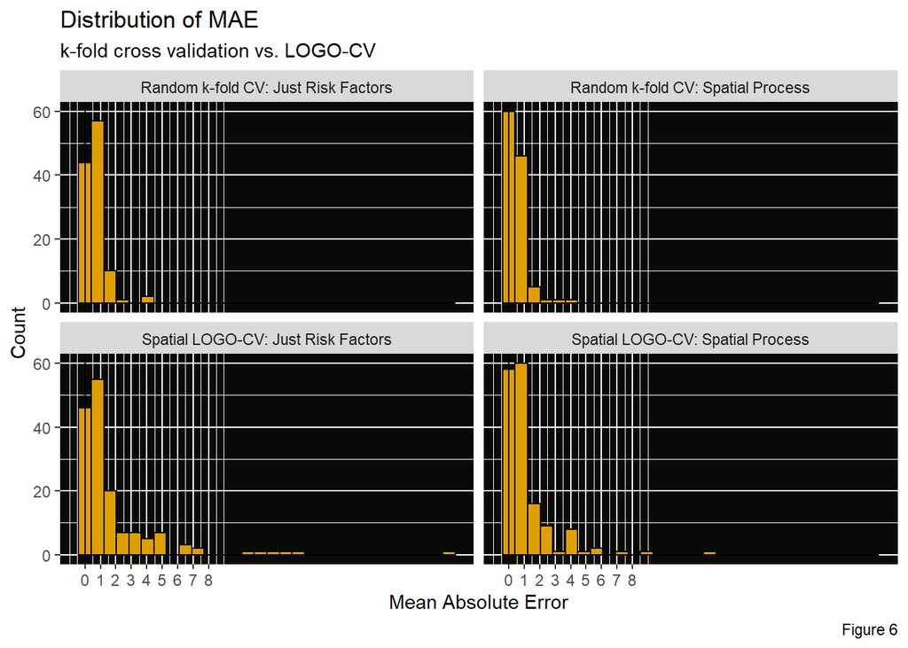

```r
error_by_reg_and_fold <-
  reg.summary %>%
  group_by(Regression, cvID) %>%
  summarize(Mean_Error = mean(Prediction - countPermit, na.rm = T),
            MAE = mean(abs(Mean_Error), na.rm = T),
            SD_MAE = mean(abs(Mean_Error), na.rm = T)) %>%
  ungroup()

error_by_reg_and_fold %>%
  ggplot(aes(MAE)) +
  geom_histogram(bins = 30, colour="black", fill = "#de9f00") +
  facet_wrap(~Regression) +
  geom_vline(xintercept = 0) + scale_x_continuous(breaks = seq(0, 8, by = 1)) +
  labs(title="Distribution of MAE", subtitle = "k-fold cross validation vs. LOGO-CV", caption = "Figure 6",
       x="Mean Absolute Error", y="Count") +
  theme(
  panel.background = element_rect(fill = "#090a07"))
```

```r
st_drop_geometry(error_by_reg_and_fold) %>%
  group_by(Regression) %>%
    summarize(Mean_MAE = round(mean(MAE), 2),
              SD_MAE = round(sd(MAE), 2)) %>%
  kable() %>%
    kable_styling("striped", full_width = F) %>%
    row_spec(1, color = "white", background = "#383120") %>%
    row_spec(2, color = "black", background = "#de9f00") %>%
    row_spec(3, color = "white", background = "#383120") %>%
    row_spec(4, color = "black", background = "#de9f00")
```

| Regression | Mean_MAE | SD_MAE |
| --- | --- | --- |
| Random k-fold CV: Just Risk Factors | 0.67 | 0.63 |
| Random k-fold CV: Spatial Process | 0.51 | 0.60 |
| Spatial LOGO-CV: Just Risk Factors | 1.85 | 3.05 |
| Spatial LOGO-CV: Spatial Process | 1.16 | 1.70 |

To further analyze our results, we can map the errors as shown in Figures 7 and 8 below. We observe that the model that contains our spatial features is more generalizable across neighborhoods as previously stated.

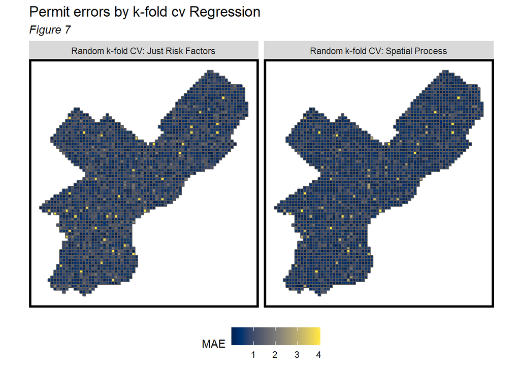

```r
#Run with K fold
error_by_reg_and_fold %>%
  filter(str_detect(Regression, "k-fold")) %>%
  ggplot() +
    geom_sf(aes(fill = MAE)) +
    facet_wrap(~Regression) +
    scale_fill_viridis(option="cividis") +
    labs(title = "Permit errors by k-fold cv Regression",
         subtitle = "Figure 7") +
    mapTheme() + theme(legend.position="bottom")
```

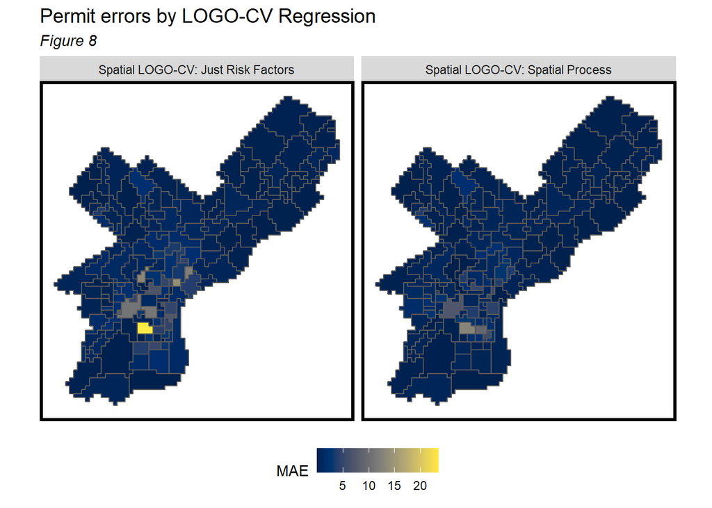

```r
#Run with LOGO-CV
error_by_reg_and_fold %>%
  filter(str_detect(Regression, "LOGO")) %>%
  ggplot() +
    geom_sf(aes(fill = MAE)) +
    facet_wrap(~Regression) +
    scale_fill_viridis(option="cividis") +
    labs(title = "Permit errors by LOGO-CV Regression",
         subtitle = "Figure 8") +
    mapTheme() + theme(legend.position="bottom")
```

As we did with our dependent variable, we can calculate a Local Moran’s I statistic to examine how the model performs in hotspots vs. coldspots.

```r
neighborhood.weights <-
  filter(error_by_reg_and_fold, Regression == "Spatial LOGO-CV: Spatial Process") %>%
    group_by(cvID) %>%
      poly2nb(as_Spatial(.), queen=TRUE) %>%
      nb2listw(., style="W", zero.policy=TRUE)

filter(error_by_reg_and_fold, str_detect(Regression, "LOGO"))  %>%
    st_drop_geometry() %>%
    group_by(Regression) %>%
    summarize(Morans_I = moran.mc(abs(Mean_Error), neighborhood.weights,
                                 nsim = 999, zero.policy = TRUE,
                                 na.action=na.omit)[[1]],
              p_value = moran.mc(abs(Mean_Error), neighborhood.weights,
                                 nsim = 999, zero.policy = TRUE,
                                 na.action=na.omit)[[3]]) %>%
  kbl(caption = "Moran's I and p-value of Spatial LOGO-CV") %>%
  kable_styling() %>%
  row_spec(1, color = "white", background = "#383120") %>%
  row_spec(2, color = "black", background = "#de9f00")
```

Moran’s I and p-value of Spatial LOGO-CV

| Regression | Morans_I | p_value |
| --- | --- | --- |
| Spatial LOGO-CV: Just Risk Factors | 0.1412690 | 0.003 |
| Spatial LOGO-CV: Spatial Process | 0.2680329 | 0.001 |

The results above unexpectedly indicate that there is more spatial variation when our spatial features are included. This suggests that our model may be over-compensating for hotspots. The next step to improve this would be to perhaps remove some of the nearest neighbor features or distance to center city feature in order to simplify and better understand the drivers behind the spatial process of construction permits.

To further understand the generalizability of our model in its current state, we plot the predictions and observations in Figure 9 below. The results actually show that our model tends to under-predict in neighborhoods of high concentrations of construction permits and over-predict in neighborhoods of low concentrations. Further exploration of neighborhood dynamics will provide more insight in the next section.

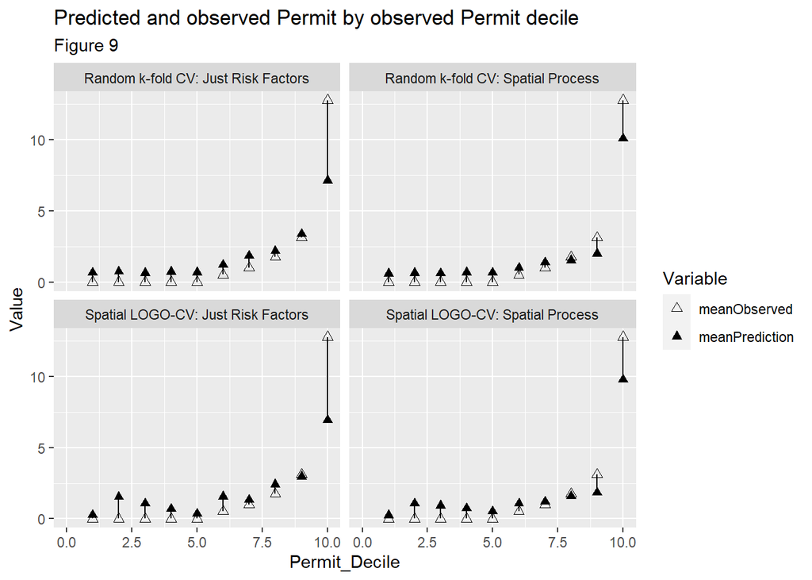

```r
st_drop_geometry(reg.summary) %>%
  group_by(Regression) %>%
    mutate(Permit_Decile = ntile(countPermit, 10)) %>%
  group_by(Regression, Permit_Decile) %>%
    summarize(meanObserved = mean(countPermit, na.rm=T),
              meanPrediction = mean(Prediction, na.rm=T)) %>%
    gather(Variable, Value, -Regression, -Permit_Decile) %>%
    ggplot(aes(Permit_Decile, Value, shape = Variable)) +
      geom_point(size = 2) + geom_path(aes(group = Permit_Decile), colour = "black") +
      scale_shape_manual(values = c(2, 17)) +
      facet_wrap(~Regression) + xlim(0,10) +
      labs(title = "Predicted and observed Permit by observed Permit decile",
           subtitle = "Figure 9")
```

### Generalizabilty by Neighborhood Context

We want to see if our model is generalizable across neighborhoods in the context of income. Income level often affects long-time residents’ ability to keep their homes and protect themselves against displacement. Below, median income at a census tract level is used to determine if tracts were above or below the city wide median income. The city wide median income level is $46,116 according to Philadelphia’s DataUSA profile.

We also recognize that racial composition of neighborhoods has a strong association with displacement and gentrification, but because many of our feature data is hyper-focused on financial characteristics of neighborhoods, we decided that an income context would be more applicable.

Below, we load census data for the City of Philadelphia.

```r
#Generalize to an income context. Below Median Income of $46,116 or above?
tracts18 <-
  get_acs(geography = "tract", variables = c("B06011_001"),
          year = 2018, state=42, county=101, geometry=T) %>%
  st_transform('EPSG:3857')  %>%
  dplyr::select(variable, estimate, GEOID) %>%
  spread(variable, estimate) %>%
  rename(MedianIncome = "B06011_001") %>%
  mutate(#percentWhite = NumberWhites / TotalPop,
         IncomeContext = ifelse(MedianIncome > 46116, "Above_Median_Income", "Below_Median_Income")) %>%
  .[neighborhoods,]
#
#   ggplot()+
#     geom_sf(data=tracts18, aes(fill=IncomeContext))+
#     #scale_color_viridis()+
#     labs(title="Income Context in Philadelphia\n2018",
#          subtitle = "Figure 9")+
#     mapTheme()
```

The summary table below presents the generalizability of the LOGO-CV results in the context of median income. We can observe that both models over-predict for neighborhoods above the median income level and under-predict for neighborhoods below the median income level. Additionally, we again observe that the Just Risk Factors model is slightly more accurate than the Spatial Process model.

```r
reg.summary %>%
  filter(str_detect(Regression, "LOGO")) %>%
    st_centroid() %>%
    st_join(tracts18) %>%
    na.omit() %>%
      st_drop_geometry() %>%
      group_by(Regression, IncomeContext) %>%
      summarize(mean.Error = mean(Error, na.rm = T)) %>%
      spread(IncomeContext, mean.Error) %>%
      kable(caption = "Mean Error by neighborhood Income context") %>%
        kable_styling("striped", full_width = F) %>%
  row_spec(1, color = "white", background = "#383120") %>%
  row_spec(2, color = "black", background = "#de9f00")
```

Mean Error by neighborhood Income context

| Regression | Above_Median_Income | Below_Median_Income |
| --- | --- | --- |
| Spatial LOGO-CV: Just Risk Factors | 0.1530299 | -0.0640734 |
| Spatial LOGO-CV: Spatial Process | 0.1914888 | -0.0690819 |

# Analyzing Results Across Time

In this section, we create kernel density maps to analyze the accuracy and generalizability of our model across time. First, we create the map for 2018 permits.

[figure not shown]

```r
permit_ppp <- as.ppp(st_coordinates(permits), W = st_bbox(final_net))
permit_KD <- spatstat::density.ppp(permit_ppp, 1000)

as.data.frame(permit_KD) %>%
  st_as_sf(coords = c("x", "y"), crs = st_crs(final_net)) %>%
  aggregate(., final_net, mean) %>%
   ggplot() +
     geom_sf(aes(fill=value)) +
     geom_sf(data = sample_n(permits, 1500), size = .5) +
     scale_fill_viridis(name = "Density", option="cividis") +
     labs(title = "Kernel density of 2019 permits",
          subtitle = "Figure 10") +
     mapTheme()
```

Next, we load the data for newly filed construction permits in 2019.

```r
permits19 <-  st_read("https://phl.carto.com/api/v2/sql?q=SELECT+*+FROM+permits+WHERE+permitissuedate+>=+'2019-01-01'+AND+permitissuedate+<+'2020-01-01'AND+typeofwork+=+'NEW+CONSTRUCTION'&filename=permits&format=geojson&skipfields=cartodb_id")%>%
  st_transform('EPSG:3857')%>%
  distinct() %>%
  .[fishnet,]
```

```r
permit_ppp <- as.ppp(st_coordinates(permits), W = st_bbox(final_net))
permit_KD <- spatstat::density.ppp(permit_ppp, 1000)

permit_KDE_sf <- as.data.frame(permit_KD) %>%
  st_as_sf(coords = c("x", "y"), crs = st_crs(final_net)) %>%
  aggregate(., final_net, mean) %>%
  mutate(label = "Kernel Density",
         Risk_Category = ntile(value, 100),
         Risk_Category = case_when(
           Risk_Category >= 90 ~ "90% to 100%",
           Risk_Category >= 70 & Risk_Category <= 89 ~ "70% to 89%",
           Risk_Category >= 50 & Risk_Category <= 69 ~ "50% to 69%",
           Risk_Category >= 30 & Risk_Category <= 49 ~ "30% to 49%",
           Risk_Category >= 1 & Risk_Category <= 29 ~ "1% to 29%")) %>%
  cbind(
    aggregate(
      dplyr::select(permits19) %>% mutate(permitCount = 1), ., sum) %>%
    mutate(permitCount = replace_na(permitCount, 0))) %>%
  dplyr::select(label, Risk_Category, permitCount)
```

The same process is repeated for risk predictions based on our model. Note: we use the predictions from LOGO-CV with the spatial features because this is the model we expected to perform the best.

```r
permit_risk_sf <-
  filter(reg.summary, Regression == "Spatial LOGO-CV: Spatial Process") %>%
  mutate(label = "Risk Predictions",
         Risk_Category = ntile(Prediction, 100),
         Risk_Category = case_when(
           Risk_Category >= 90 ~ "90% to 100%",
           Risk_Category >= 70 & Risk_Category <= 89 ~ "70% to 89%",
           Risk_Category >= 50 & Risk_Category <= 69 ~ "50% to 69%",
           Risk_Category >= 30 & Risk_Category <= 49 ~ "30% to 49%",
           Risk_Category >= 1 & Risk_Category <= 29 ~ "1% to 29%")) %>%
  cbind(
    aggregate(
      dplyr::select(permits19) %>% mutate(permitCount = 1), ., sum) %>%
      mutate(permitCount = replace_na(permitCount, 0))) %>%
  dplyr::select(label,Risk_Category, permitCount)
```

The results are presented below in Figure 11.

In this map, we see a more specific and localized heat map from the risk predictions rather than the kernel density map. The importance of localization cannot be understated as risk can vary from block to block and the resources needed for each follows the prediction. It appears that the kernel density map inaccurately predicted where permits were filed and in most cases overstated the risk, leading to a misallocation of resources. In our approach to allocating resources on a specific block or household level, the risk predictions model is more appropriate.

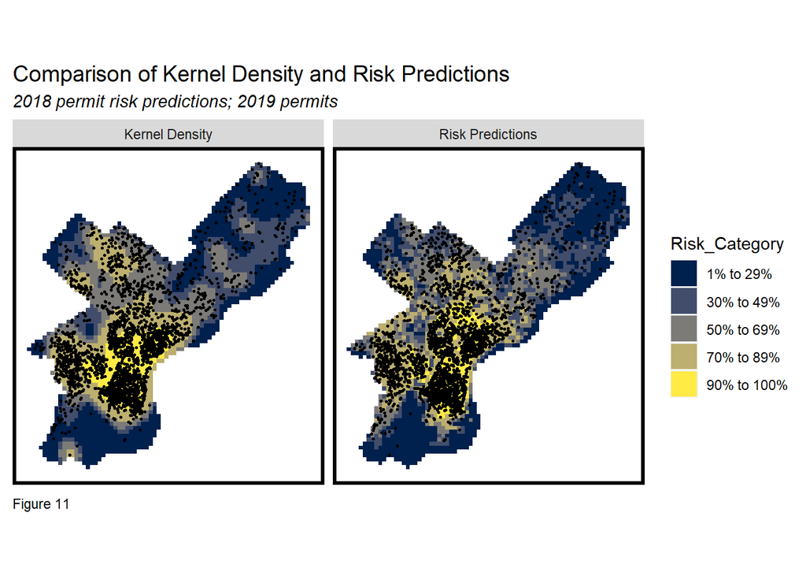

```r
rbind(permit_KDE_sf, permit_risk_sf) %>%
  na.omit() %>%
  gather(Variable, Value, -label, -Risk_Category, -geometry) %>%
  ggplot() +
    geom_sf(aes(fill = Risk_Category), colour = NA) +
    geom_sf(data = sample_n(permits19, 3000), size = .5, colour = "black") +
    facet_wrap(~label, ) +
    scale_fill_viridis(discrete = TRUE, option="cividis") +
    labs(title="Comparison of Kernel Density and Risk Predictions",
         subtitle="2018 permit risk predictions; 2019 permits",
         caption = "Figure 11") +
    mapTheme()
```

The bar chart below displays the accuracy of our predictions as well. In the riskiest category, kernel density predicts more accurately while in the second riskiest, the risk predictions model does better. However, at both of these breaks, the bars are basically even. We would hope to see risk predictions do substantially better in order to prove its effectiveness over kernel density.

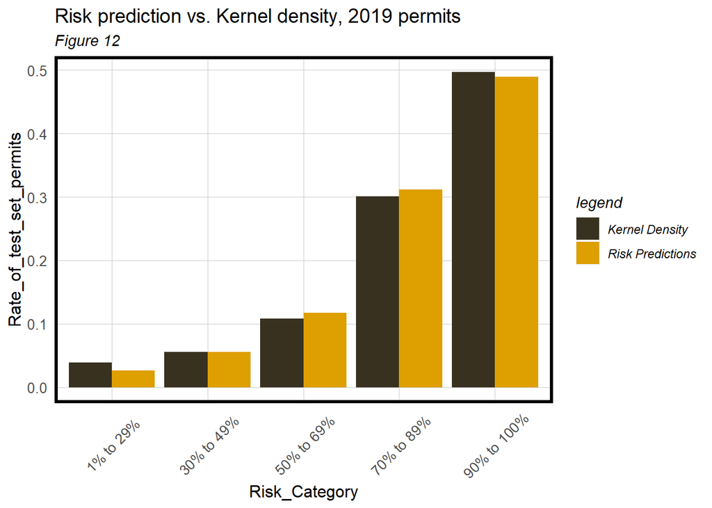

```r
rbind(permit_KDE_sf, permit_risk_sf) %>%
  st_set_geometry(NULL) %>% na.omit() %>%
  gather(Variable, Value, -label, -Risk_Category) %>%
  group_by(label, Risk_Category) %>%
  summarize(countPermits = sum(Value)) %>%
  ungroup() %>%
  group_by(label) %>%
  mutate(Rate_of_test_set_permits = countPermits / sum(countPermits)) %>%
    ggplot(aes(Risk_Category,Rate_of_test_set_permits)) +
      geom_bar(aes(fill=label), position="dodge", stat="identity") +
      scale_fill_manual ("legend", values = c("Kernel Density" = "#383120", "Risk Predictions" = "#de9f00")) +
      labs(title = "Risk prediction vs. Kernel density, 2019 permits",
           subtitle = "Figure 12") +
      plotTheme() + theme(axis.text.x = element_text(angle = 45, vjust = 0.5))
```

# Conclusion

As we hope we have demonstrated throughout this use case and model, gentrification remains an integral part of the urban fabric and predicting where it will occur in order to plan accordingly is beneficial to all actors within city life. Philadelphia has a dearth of decent housing units and it is in the city’s best interest to maintain stability in resident’s lives by helping them maintain ownership. Additionally, developers might see less resistance to their plans if the process was transparent, predictable and individuals could rest assured that they wouldn’t be priced out or face displacement.

The business as usual approach to this particular urban problem does not include a plan for residents when an area has gentrified to the point that causes displacement. Instead it leaves individuals stressed and worried about their ability to pay their bills and remain in their home. Our model, in the hands of groups like Affordable Housing Advocates, can organize individual homeowners and bring collective help to ensuring that communities are not split. It connects organizations with individuals and proactively plans ahead of time before crisis hits.

By presenting risk scores on our map, our model connects the nebulous threat of gentrification with a specific number in order to easily prioritize and assess which neighborhoods and further which blocks and households need help most urgently. We want to emphasize that unlike in the predictive policing example in which this model was presented, there is a much smaller consequence in overpredicting gentrification. While we obviously want our model to be accurate, the consequence in overpredicting is that homes are prepared unnecessarily.

As mentioned, our use case attempts to localize as much as possible as ultimately we want to be able to prepare the smallest unit of area: the home. Therefore we mainly chose features that exist as point data and also occupy fixed space. It is important that we used data representing brick and mortar buildings in contrast to events like crime or 311 data as we recognize that gentrification does not happen in an instant in the way a crime does, nor is it particularly mobile or suffer from the same bias in the data reporting. Gentrification is a long process usually over the course of five to ten years, and everyone’s definition of it varies. Thus we chose to also use predictors that were more consistent across time and could not see huge spikes in change from one day to the next.

One limitation of our model is that it can only predict for one year at a time. For future research, we would try to build this problem as a space time model and predict spatially as well as temporally. The overall effect would be a map in which one can see the movement of gentrification risk across the city block by block as we go further into the future. Additionally, our dependent variable of new construction permits might present a skewed picture of where gentrification actually occurs. There is a long time between the process of filing a permit with the city and building something that might have an impact on its urban environment. Because our model works over a time span of years and not hours or days, it is much harder to predict accurate patterns as outside events like climate change or global pandemics that shutdown economic life occur somewhat randomly and disrupt the process of development.

In addition to adding a stronger temporal aspect, our next steps might look at the acquisition of properties or land use by realty companies to see where investments are being made. This data would emphasize where the dollars are flowing across the city. However, it would also be limited in the long time span between an initial investment and a rise in property tax value of individual homes.

Overall, we hope our model, in the right hands, can best help keep our city, Philadelphia, fair and accessible to all its residents. If done well, this model can be easily replicated for other cities and areas of the country. As strong believers in home ownership and racial and economic equity, we are proud that our model creates a clear vision for change in the city and for action steps to take into it’s future.